# Combining single- and repeated-visit occupancy models to make the best of monitoring surveys: Appendix

2019-10-28

**Authors** *Valentin Lauret, Hélène Labach, Matthieu Authier, Olivier Gimenez*

In this Appendix, we present how we built a hybrid multi-method occupancy model analysing the aerial surveys with repeated-visit occupancy models, and the at-sea surveys with single-visit (SV) occupancy models.

# Standard occupancy

Each detection `y[i,j]` at site *i* and visit *j* is taken in a Bernoulli distribution with parameter `mu[i,j]`.

`y[i,j]~dbern(mu[i,j])`

The `mu` parameter is defined as `mu[i,j] = p[i,j] * z[i,j]`.  
`p[i,j]` is the probability of detecting the species at site i, during visit j.

The latent ecological state, i.e. the occupancy status, of site i is taken in a Bernoulli distribution of parameter `psi`

`z[i]~dbern(psi[i])`.

Then `psi` represent the occupancy probability of site *i*.

`psi` is modelled as a logistic regressions of the environmental covariates: bathymetry and SST.`p` is modeled as a logistic regression of sampling effort. `alpha.psi`, `alpha.p`, `beta.sst`, `beta.bathy`, and `beta.eff` are unknown parameters:

`logit(psi[i]) = alpha.psi + beta.sst * SST[i] + beta.bathy * BATHY[i]`

`logit(p[i,j]) = alpha.p + beta.eff * EFF[i,j]`

`SST`, `BATHY`, and `EFF` are the dataframes that contain the numerical values of respectively SST, bathymetry, and sampling effort.

# Hybrid modelling

In the hybrid multi-method model, there are 2 different detection processes.

We separated a aerial detection matrix `y_samm` (with 4 columns as repeated visit at sites), from the at-sea detection matrix with a single visit `y_gdegem`, i.e. 1 column.

There are 2 trials with Bernoulli distributions, with their associated `p`.

- `y_samm[i,j]~dbern(mu_samm[i,j])` , with `mu_samm[i,j] = z[i] * p_samm[i,j]`
- `y_gdegem[i]~dbern(mu_gdegem[i])`, with `mu_gdegem[i] = z[i] * p_gdegem[i]`  
  With `logit(p_gdegem[i]) = alpha.p_gdegem + beta.eff.gd*eff.gd[i]`

and `logit(p_samm[i,j]) = alpha.p_samm + beta.eff.samm * eff.samm[i,j] + beta.occ2 * equals(j,2) + beta.occ3 * equals(j,3) + beta.occ4 * equals(j,4)`

Hereafter, you would find the JAGS formulation of this occupancy model.

```r
# Specify model in BUGS language
sink("mixed_std_sv.jags")
cat("
    model {

   # priors

    alpha.psi ~ dnorm(0,0.444) # occupancy intercept
    alpha.p_samm ~ dnorm(0,0.444) # detection samm intercept
    alpha.p_gdegem ~ dnorm(0,0.444) # detection gdegem intercept

    beta.sst ~ dnorm(0,0.444) # slope sst effect
    beta.bathy ~ dnorm(0,0.444) # slope bathy effect
    beta.eff.samm ~ dnorm(0,0.444)  # slope SAMM survey effort effect
    beta.eff.gd ~ dnorm(0,0.444)    # slope GDEGeM survey effort effect
    beta.occ2 ~ dnorm(0,0.444) # occasion effect
    beta.occ3 ~ dnorm(0,0.444) # occasion effect
    beta.occ4 ~ dnorm(0,0.444) # occasion effect

    # Ecological submodel: Define state conditional on parameters

    ### initialisation: on met a chaque site la valeur 0 ou 1 selon la loi de bernouilli pour l'annee 1

   for (i in 1:nsite){
      z[i] ~ dbern(psi[i])

     logit(psi[i]) <- lpsi[i]

     lpsi[i] <- alpha.psi + beta.sst * SST[i] + beta.bathy * BATHY[i]

  }  # i

     ### Observation model

    for(i in 1:nsite){
    ###p.gdegem

     mu.p_gdegem[i] <- z[i] * p_gdegem[i]

    logit(p_gdegem[i]) <- alpha.p_gdegem + beta.eff.gd*eff.gd[i]

   y_gdegem[i] ~ dbern(mu.p_gdegem[i])

    } #i

for(i in 1:nsite){
   for (j in 1:nrep){

    mu.p_samm[i,j] <- z[i] * p_samm[i,j]

    logit(p_samm[i,j]) <- lp_samm[i,j]

    lp_samm[i,j] <- alpha.p_samm + beta.eff.samm * eff.samm[i,j] + beta.occ2 * equals(j,2) + beta.occ3 * equals(j,3) + beta.occ4 * equals(j,4)

    y_samm[i,j] ~ dbern(mu.p_samm[i,j])


    } #j

  } #i

    }#fin du modele
    ", fill = TRUE)

sink()
```

# Results

Hereafter, we show the effect size the environmental covariates on the estimated occupancy probability (psi).

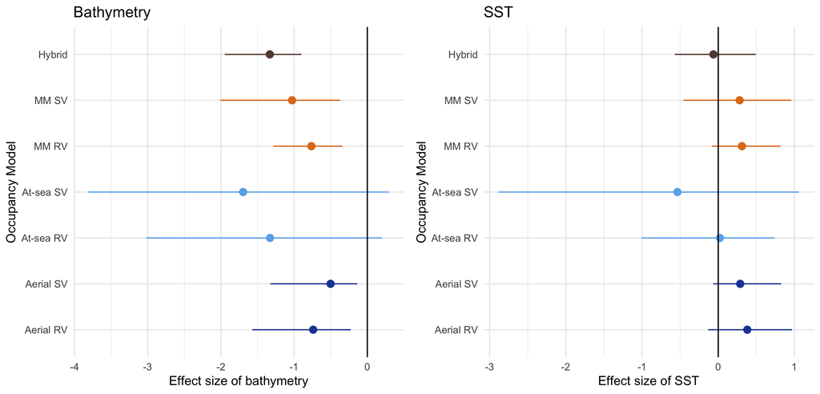

Figure 1: *Effect size of sea surface temperature (SST) and bathymetry on the proportion of area occupied by Bottlenose dolphins (*Tursiops truncatus*) obtained with the 2 monitoring programs. The a posteriori mean is given with the associated 95% credible interval. “**SV**” refers to single-visit occupancy models. “**RV**” refers to repeated-visit occupancy models. “**MM**” stands for multi-methods occupancy models, in which aerial surveys and at-sea surveys are combined. **Hybrid** refers to the model described above in this appendix. Estimates are given on the logit scale.*

Now, we look at the map of the probability of occupancy. From the posterior mean of each occupancy models parameters, we generated the probability that site *i* is used by bottlenose dolphins:

$$logit(\psi_{i}) = Intercept + \beta_{bathymetry}bathymetry_{i} + \beta_{SST}SST_{i}$$

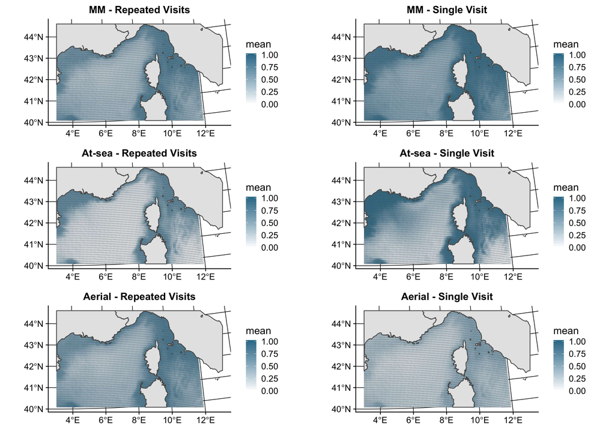

Map of projected Psi for other models

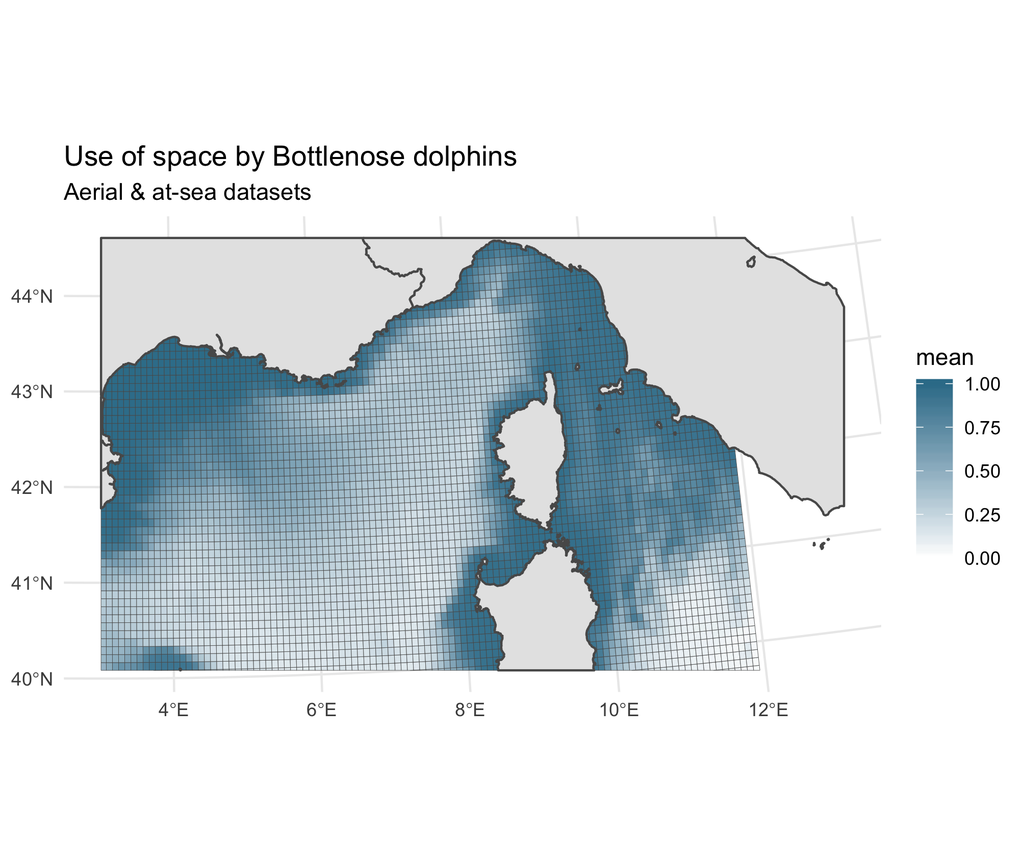

Figure 2: *Map of projected Psi for the Hybrid model*

This hybrid model highlights the flexibility of occupancy model to better fit with the sampling designs of non-standardized datasets. However, the separated formulation of the detection process into 2 matrices is relevant only if the monitoring programs are independant. Dependance between monitoring devies requires to model explicitly the covariation between detection probabilities (Clare et al. 2017)

# References

Clare J, McKinney ST, DePue JE, Loftin CS. 2017. Pairing field methods to improve inference in wildlife surveys while accommodating detection covariance. Ecological Applications 27:2031–2047.